# Genética de Populações: F - Stats

Vitor Bialetzki Cristiano

2026-09-12

# INTRODUÇÃO

## 1. Introdução e Contextualização

A caracterização da diversidade e da estrutura populacional é um passo fundamental na genética de populações, na conservação do germoplasma e no melhoramento genético. Neste estudo, avaliou-se um painel de linhagens de milho (*Zea mays* L.) oriundas do projeto **Genome to Fields (G2F)**, genotipado com marcadores moleculares do tipo **SNP** (*Single Nucleotide Polymorphism*).

A partir da análise de agrupamento hierárquico (*Hierarchical Clustering*) aplicada à matriz de relacionamento genômico, a população foi particionada em **três subgrupos principais** ($k = 3$). A avaliação da divergência genética entre esses subgrupos é crucial para identificar padrões heteróticos, compreender a deriva genética e evitar vieses por subestrutura em análises genômicas posteriores.

> **Fundamentação Teórica:** Para quantificar a diferenciação genética de forma estatisticamente rigorosa e sem vieses decorrentes de amostragem ou tamanhos populacionais desiguais, adotamos a abordagem de Análise de Variância (ANOVA) ponderada proposta por **Weir & Cockerham (1984)** (*Estimating F-Statistics for the Analysis of Population Structure*, *Evolution*).

### Objetivos do Estudo

1. **Partição das Subpopulações:** Mapear a distribuição dos genótipos nos $3$ grupos identificados via *heatmap/PCA* e extrair as frequências do alelo de referência locus a locus.
2. **Decomposição da Variância Genômica:** Calcular os componentes de variância para cada SNP $u$ do genoma:
   - $a_u$: Variância atribuída às diferenças **entre populações**.
   - $b_u$: Variância entre **indivíduos dentro das populações**.
   - $c_u$: Variância entre **gametas dentro dos indivíduos** (heterozigosidade).
3. **Estimativa Não-Viesada do $F_{ST}$ ($\theta$):** Acumular os componentes de variância de todos os marcadores ao longo do genoma para obter o índice de fixação global:

$$\hat{\theta} = \frac{\sum a_u}{\sum a_u
+ \sum b_u + \sum c_u}$$
Nesta etapa, realizOou-se o carregamento dos pacotes necessários e a leitura do arquivo **VCF** (*Variant Call Format*), previamente filtrado pelo controle de qualidade.

[output not shown]

[output not shown]

Para quantificar o grau de similaridade e o relacionamento genético entre as linhagens de milho, construída a **Matriz de Parentesco Genômico ($G$)** proposta por **VanRaden (2008)** (Método 1).

A matriz $G$ substitui o pedigree tradicional por dados genômicos reais, centralizando as dosagens alélicas pelas frequências de cada marcador no painel:

$$G = \frac{Z Z^T}{2 \sum_{j=1}^p p_j (1 -
p_j)}$$

```r
geno_num[geno_num == 1] <- 2
dim(geno_num)
```

```
## [1]   312 68979
```

```r
M <- geno_num
n_ind <- nrow(M)
p <- colSums(M)/(2*n_ind)
P <- matrix(2*p, nrow = nrow(M), ncol = ncol(M), byrow = TRUE)

Z <- M-P


Numerador <- Z%*%t(Z)
Denominador <- 2*sum(p*(1-p))
G <- Numerador/Denominador
```

Para investigar a subestrutura populacional do painel de milho, aplicaram-se métodos de ordenamento e agrupamento a partir da Matriz de Parentesco Genômico ($G$).

A Análise de Componentes Principais (PCA) foi executada via `prcomp()`, utilizando a matriz $G$ padronizada. Em paralelo, calculou-se a matriz de distâncias euclidianas entre os perfis de parentesco para a realização do agrupamento hierárquico (`hclust()`). A árvore gerada foi particionada em **três grupos principais** ($k = 3$), o que permitiu identificar e isolar os indivíduos pertencentes a cada subpopulação para as análises posteriores.

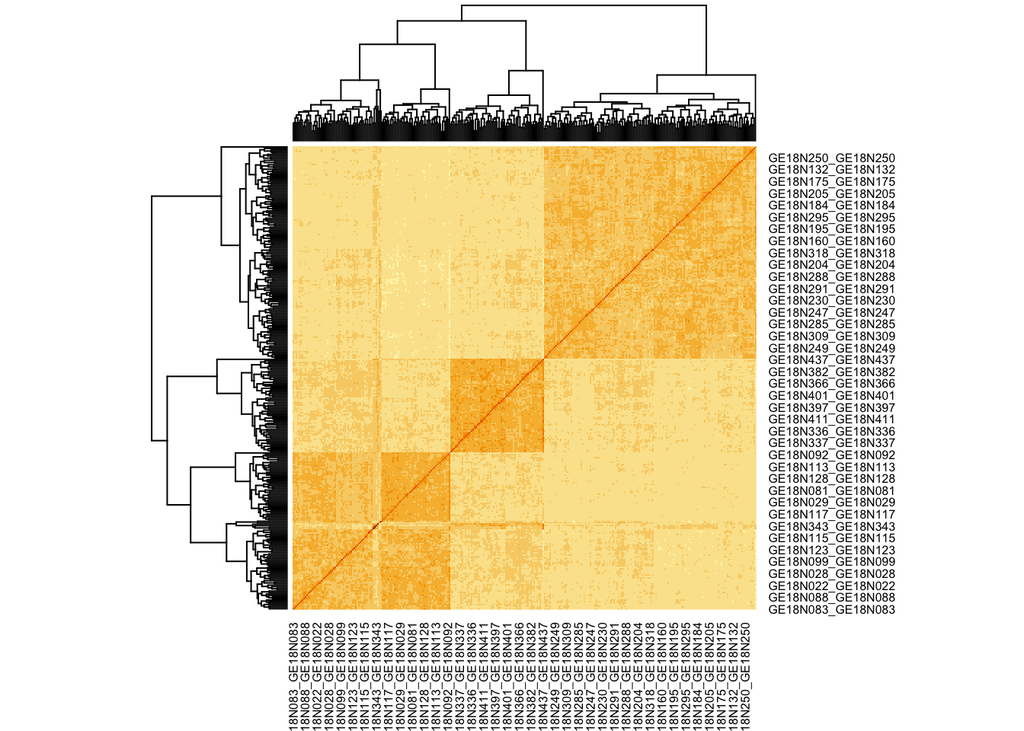

```r
heatmap(G)
```

```r
pcA_milho <- prcomp(G, center = TRUE, scale. = TRUE)
summary(pcA_milho)
```

```
## Importance of components:
##                           PC1    PC2     PC3     PC4     PC5     PC6     PC7
## Standard deviation     13.111 8.2160 3.38913 2.69571 2.52380 2.38421 2.10253
## Proportion of Variance  0.551 0.2163 0.03681 0.02329 0.02042 0.01822 0.01417
## Cumulative Proportion   0.551 0.7673 0.80415 0.82744 0.84785 0.86607 0.88024
##                            PC8    PC9    PC10    PC11    PC12    PC13   PC14
## Standard deviation     1.97551 1.8862 1.48559 1.40742 1.30619 1.26892 1.1711
## Proportion of Variance 0.01251 0.0114 0.00707 0.00635 0.00547 0.00516 0.0044
## Cumulative Proportion  0.89275 0.9042 0.91123 0.91757 0.92304 0.92820 0.9326
##                           PC15    PC16    PC17   PC18    PC19    PC20   PC21
## Standard deviation     1.13847 1.04689 1.01795 0.9341 0.88897 0.85826 0.8280
## Proportion of Variance 0.00415 0.00351 0.00332 0.0028 0.00253 0.00236 0.0022
## Cumulative Proportion  0.93675 0.94027 0.94359 0.9464 0.94892 0.95128 0.9535
##                           PC22    PC23    PC24   PC25    PC26    PC27    PC28
## Standard deviation     0.79317 0.78326 0.76354 0.7489 0.70475 0.69536 0.67334
## Proportion of Variance 0.00202 0.00197 0.00187 0.0018 0.00159 0.00155 0.00145
## Cumulative Proportion  0.95549 0.95746 0.95933 0.9611 0.96272 0.96427 0.96572
##                           PC29    PC30    PC31   PC32    PC33    PC34    PC35
## Standard deviation     0.64406 0.63185 0.62215 0.6113 0.59629 0.58236 0.55571
## Proportion of Variance 0.00133 0.00128 0.00124 0.0012 0.00114 0.00109 0.00099
## Cumulative Proportion  0.96705 0.96833 0.96957 0.9708 0.97191 0.97299 0.97398
##                           PC36    PC37    PC38    PC39   PC40    PC41    PC42
## Standard deviation     0.53257 0.52725 0.52264 0.50711 0.5008 0.48372 0.47918
## Proportion of Variance 0.00091 0.00089 0.00088 0.00082 0.0008 0.00075 0.00074
## Cumulative Proportion  0.97489 0.97578 0.97666 0.97748 0.9783 0.97904 0.97977
##                           PC43    PC44   PC45   PC46    PC47    PC48   PC49
## Standard deviation     0.46173 0.45467 0.4338 0.4310 0.41837 0.40773 0.3943
## Proportion of Variance 0.00068 0.00066 0.0006 0.0006 0.00056 0.00053 0.0005
## Cumulative Proportion  0.98046 0.98112 0.9817 0.9823 0.98288 0.98341 0.9839
##                           PC50    PC51    PC52    PC53    PC54   PC55    PC56
## Standard deviation     0.38915 0.38299 0.37363 0.36643 0.36129 0.3531 0.34817
## Proportion of Variance 0.00049 0.00047 0.00045 0.00043 0.00042 0.0004 0.00039
## Cumulative Proportion  0.98439 0.98486 0.98531 0.98574 0.98616 0.9866 0.98695
##                           PC57    PC58    PC59    PC60    PC61    PC62    PC63
## Standard deviation     0.34154 0.33881 0.33409 0.32115 0.32036 0.31876 0.31241
## Proportion of Variance 0.00037 0.00037 0.00036 0.00033 0.00033 0.00033 0.00031
## Cumulative Proportion  0.98732 0.98769 0.98805 0.98838 0.98871 0.98903 0.98935
##                          PC64    PC65    PC66    PC67    PC68    PC69    PC70
## Standard deviation     0.3075 0.29909 0.29790 0.28813 0.28540 0.27816 0.27615
## Proportion of Variance 0.0003 0.00029 0.00028 0.00027 0.00026 0.00025 0.00024
```

[output cut: 126 more lines]

[output not shown]

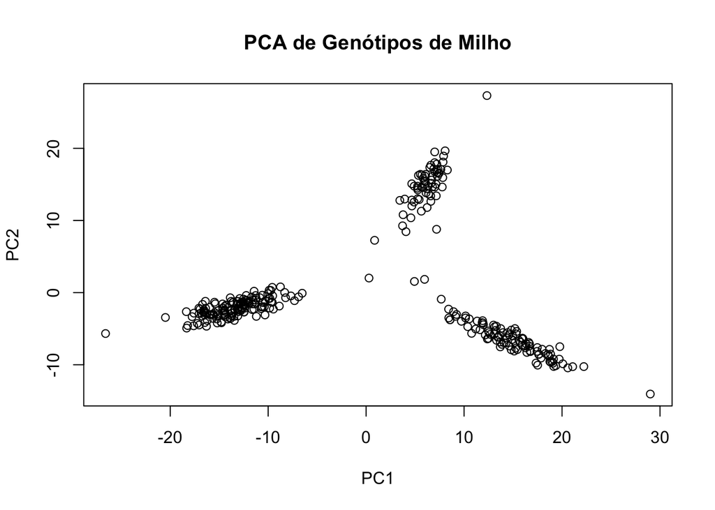

```r
scores <- pcA_milho$x
plot(scores[,1], scores[,2],
     xlab = "PC1", ylab = "PC2",
     main = "PCA de Genótipos de Milho")
```

```r
#### ver os grupos
distancia <- dist(G)
hc <- hclust(distancia)

grupos <- cutree(hc, k = 3)
df_grupos <- data.frame(
  Genotipo = names(grupos),
  Grupo = as.factor(grupos)
)

ind_grupo1 <- names(grupos[grupos == 1])
ind_grupo2 <- names(grupos[grupos == 2])
ind_grupo3 <- names(grupos[grupos == 3])
```

## Parâmetros da Estrutura Populacional

Esses três parâmetros estão relacionados por:

$$f = \frac{F-\theta}{1-\theta}.$$

Os autores mostram ainda que, para todos os efeitos práticos, esses parâmetros correspondem às estatísticas de F de Wright da seguinte forma:

$$F = F_{IT},$$

$$\theta = F_{ST},$$

$$f = F_{IS}.$$

Weir & Cockerham mantêm, entretanto, a notação $F$, $\theta$ e $f$ ao longo do desenvolvimento, uma vez que essas quantidades são definidas como parâmetros populacionais, independentemente dos aspectos específicos do esquema de amostragem.

## Cálculo dos Parâmetros

As esperanças desses componentes de variância são:

$$E(a) = p(1-p)\theta,$$

$$E(b) = p(1-p)(F-\theta),$$

$$E(c) = p(1-p)(1-F),$$

em que $p$ é a frequência esperada do alelo na população ancestral.

e

Equivalentemente, as relações podem ser expressas como:

$$1-\hat{F}
=
\frac{c}{a+b+c},$$

e

$$1-\hat{f}
=
\frac{c}{b+c}.$$

No R, temos:

```r
### VAMOS USAR R COMO TRES
r <- 3
### com base no heat map
########## FORMULAS DOS COMPONENTES DE VARIANICIA

#the average sample size
n <- n_ind/3
n
```

```
## [1] 104
```

```r
n_i_r <- c(length(ind_grupo1), length(ind_grupo2), length(ind_grupo3))
n_i_r
```

```
## [1] 143 106  63
```

```r
n_c <- (r*n - (sum(n_i_r^2)) / (r * n)) / (r - 1)
n_c
```

```
## [1] 98.86218
```

```r
# the average sample frequency of allele A - USANDO A MATRIZ DE DOSAGEM

N1 <- length(ind_grupo1)
N1
```

```
## [1] 143
```

```r
N2 <- length(ind_grupo2)
N2
```

```
## [1] 106
```

```r
N3 <- length(ind_grupo3)
N3
```

```
## [1] 63
```

```r
N_total <- N1 + N2 +N3
N_total
```

```
## [1] 312
```

```r
p1 <- colMeans(M[ind_grupo1, ], na.rm = TRUE)/2
p2 <- colMeans(M[ind_grupo2, ], na.rm = TRUE)/2
p3 <- colMeans(M[ind_grupo3, ], na.rm = TRUE)/2
head(p1)
```

```
## S1_210603 S1_210820 S1_215289 S1_561528 S1_561583 S1_689689
## 0.4895105 0.0000000 0.0000000 0.0000000 0.4895105 0.0000000
```

```r
head(p2)
```

```
##  S1_210603  S1_210820  S1_215289  S1_561528  S1_561583  S1_689689
## 0.01886792 0.32075472 0.14150943 0.16037736 0.56603774 0.01886792
```

```r
head(p3)
```

```
##  S1_210603  S1_210820  S1_215289  S1_561528  S1_561583  S1_689689
## 0.00000000 0.00000000 0.01587302 0.01587302 0.39682540 0.38095238
```

```r
pA <- ((N1 * p1) + (N2 * p2) + (N3 * p3)) / (r * n)
head(pA)
```

```
##  S1_210603  S1_210820  S1_215289  S1_561528  S1_561583  S1_689689
## 0.23076923 0.10897436 0.05128205 0.05769231 0.49679487 0.08333333
```

```r
# the sample variance of allele A frequencies
n_i <- c(N1, N2, N3)
s2 <- (N1 * (p1 - pA)^2 + N2 * (p2 - pA)^2 + N3 * (p3 - pA)^2) / ((r - 1) * n)
head(s2)
```

```
##   S1_210603   S1_210820   S1_215289   S1_561528   S1_561583   S1_689689
## 0.085038873 0.034617943 0.006336547 0.008191474 0.005506866 0.033720800
```

```r
# the average heterozygote frequency for allele A.
## como sao linhagens homozigoticas, a heterozigosidade é ZERO
h<-0

# Observed components of variance: a for between populations; b for between individuals within populations; and c for between gametes within individual

a_u <- (n / n_c) * (s2 - (1 / (n - 1)) * (pA * (1 - pA) - ((r - 1) / r) * s2 - (1 / 4) * h))
head(a_u)
```

```
##   S1_210603   S1_210820   S1_215289   S1_561528   S1_561583   S1_689689
## 0.088224309 0.035661030 0.006212099 0.008117721 0.003277332 0.034922672
```

```r
A_total <- sum(a_u, na.rm = TRUE)
A_total
```

```
## [1] 3893.134
```

```r
b_u <- (n / (n - 1)) * (pA * (1 - pA) - ((r - 1) / r) * s2 - ((2 * n - 1) / (4 * n)) * h)
head(b_u)
```

```
##  S1_210603  S1_210820  S1_215289  S1_561528  S1_561583  S1_689689
## 0.12199524 0.07473896 0.04485918 0.04937771 0.24870992 0.05443174
```

```r
B_total <- sum(b_u, na.rm = TRUE)
B_total
```

```
## [1] 8832.487
```

```r
c_u <- 0.5 * h
head(c_u)
```

```
## [1] 0
```

```r
C_total <- sum(c_u, na.rm = TRUE)
C_total
```

```
## [1] 0
```

```r
# F, the correlation of genes within individuals "inbreeding"

F_it <- 1 - (C_total / (A_total + B_total + C_total))
F_it
```

```
## [1] 1
```

```r
# 0, the correlation of genes of different individuals in the same population ("coancestry")

teta <- A_total / (A_total + B_total + C_total)
teta
```

```
## [1] 0.3059288
```

```r
# f the correlation of genes within individuals within populations

F_is <- 1 - (C_total / (B_total + C_total))
F_is
```

```
## [1] 1
```

```r
# The three parameters are related by
f <- ((F_it - teta)/(1-teta))
f
```

```
## [1] 1
```

## Interpretação dos Parâmetros e Resultados

Sewell Wright (1921) introduziu o **Índice de Fixação ($F$)** para medir a redução na heterozigosidade esperada em diferentes níveis de uma hierarquia populacional sob o modelo de Hardy-Weinberg. Embora a lógica conceitual se mantenha intacta, B. S. Weir e C. C. Cockerham (1984) adaptaram a notação simbólica da hierarquia populacional estabelecida por Wright para deixá-la com um background estatístico rigoroso. Enquanto Wright definia a estrutura populacional por meio de subscritos que representavam os níveis hierárquicos comparados, tais como: $S$ (*subpopulations*), $R$ (*regional aggregates*), $T$ (População Total) em coeficientes como $F_{SR}$, $F_{RT}$ e $F_{ST}$. No seu trabalho, Weir & Cockerham fizeram apenas uma pequena mudança na hierarquia dos índices, em relação a Wright, onde estes definiram os índices: $I$ (Indivíduo), $S$ (Subpopulação), $R$ (Região) e $T$ (População Total) em coeficientes como $F_{IS}$, $F_{ST}$ e $F_{IT}$. Weir e Cockerham, no mesmo estudo, mostraram a equivalência dos índices clássicos com: $F$, $\theta$ e $f$. Nessa convenção, estabeleceu-se a equivalência direta em que $F = F_{IT}$, $\theta = F_{ST}$ e $f = F_{IS}$, permitindo traduzir a hierarquia de Wright para a estimação estatística não viesada por meio de componentes de variância.

Essa hierarquia, usada por B. S. Weir e C. C. Cockerham (1984) é composta por três níveis principais:

- **$I$ (Indivíduo):** O nível genotípico individual.
- **$S$ (Subpopulação):** A população local ou subdivisão reprodutiva.
- **$T$ (População Total):** O conjunto total combinado de todas as subpopulações (metapopulação).

Em seu trabalho clássico, B. S. Weir e C. C. Cockerham (1984) redefiniram as estatísticas $F$ clássicas em termos das correlações genéticas desenvolvidas por Cockerham (1969, 1973):

O parâmetro $\theta$ representa a correlação entre genes de indivíduos diferentes dentro da mesma população e corresponde, para fins práticos, a $F_{ST}$:

$$\theta = F_{ST}.$$

O parâmetro $F$ representa a correlação entre genes dentro dos indivíduos e corresponde a $F_{IT}$:

$$F = F_{IT}.$$

O parâmetro $f$ representa a correlação entre genes dentro dos indivíduos nas populações e corresponde a $F_{IS}$:

$$f = F_{IS}.$$

Com base nas definições supracitadas, o seguinte resultado foi alcançado:

```r
# F (F_IT): Correlação de genes dentro dos indivíduos em relação à população total
F_it <- 1 - (C_total / (A_total + B_total + C_total))
F_it
```

```
## [1] 1
```

```r
# theta (F_ST): Correlação de genes de indivíduos diferentes na mesma subpopulação
teta <- A_total / (A_total + B_total + C_total)
teta
```

```
## [1] 0.3059288
```

```r
# f (F_IS): Correlação de genes dentro dos indivíduos em relação à sua subpopulação
F_is <- 1 - (C_total / (B_total + C_total))
F_is
```

```
## [1] 1
```

Em relação à diferenciação entre os grupos, o parâmetro $\theta$ ($F_{ST}$), que mensura a correlação entre genes de indivíduos distintos pertencentes à mesma subpopulação, apresentou o valor de $0,3059288$. Wright (1978) propôs diretrizes qualitativas nas quais valores de 0 a 0,05 indicam pouca diferenciação; de 0,05 a 0,15, diferenciação moderada; de 0,15 a 0,25, grande diferenciação; e valores superiores a 0,25, diferenciação muito grande. No presente estudo, o valor obtido de $\theta \approx 0,31$ enquadra-se na categoria de diferenciação muito grande, indicando que aproximadamente 30,6% da variabilidade genética total do painel é explicada por diferenças nas frequências alélicas entre as subpopulações.

A magnitude do estimador $\theta$ encontra validação direta no *heatmap* de similaridade genômica e parentesco. A análise conjunta da matriz de distâncias e da PCA revela a formação clara de três grupos genéticos distintos ao longo da diagonal principal. Os blocos em tonalidade laranja escuro situados sobre a diagonal demonstram uma elevada coancestria e similaridade interna entre as linhagens pertencentes ao mesmo subgrupo. Em contrapartida, as regiões intergrupo, representadas por tonalidades amarelas e mais claras fora da diagonal, evidenciam a baixa similaridade genômica entre linhagens de grupos diferentes. Essa discrepância visual entre os blocos internos e externos sustenta a elevada taxa de divergência populacional estimada estatisticamente.

Em suma, os dados do painel *Genomes to Fields* mostram um quadro biológico coerente de linhagens completamente endogâmicas ($f = 1$ e $F = 1$) distribuídas em uma estrutura populacional fortemente divergente ($\theta = 0,3059288$). O alinhamento entre as estimativas de ANOVA, a classificação teórica de Wright e a separação gráfica do *heatmap* em três clusters isolados confirma que o germoplasma avaliado possui uma estrutura genética bem definida, marcada pela fixação de blocos alélicos distintos em cada subpopulação.